# Overview of the IPython notebook

```python
from IPython.display import HTML
```

```python
%load_ext load_style
```

```python
%load_style talk.css
```

Python is an **interpreted** language (more on that later), and comes with an interactive prompt (like a terminal shell) in which you can enter Python expressions and inspect the outputs.

If you want to use python interactively, there are several options:

Python ships with an interactive interpreter

[figure not shown]

IPython is an enhanced interactive interpreter, developped for scientific development, adding e.g. history, tab-completion, interactive help, and lots and lots of goodies:

[figure not shown]

Since 2005, the IPython development team has introduced the **IPython notebook**. This is a web application, running in the browser, that is connected to a Python kernel running in the background.

```python
HTML('<iframe src=http://ipython.org/notebook.html width=900 height=350></iframe>')
```

[interactive chart not shown]

It behaves as an **interactive notebook**, in which you can weave Python code and outputs, figures generated from Python / matplotlib, images (either local and remote), websites, videos and richly formatted comments using markdown, which is a superset of HTML with a very simple syntax (see here for more)

It is structured into executable cells, into which by default you can run arbitrary python code

It has a sophisticated tab completion and help system

The power of IPython comes in part because of its numerous extensions and *magic* functions

And finally you can *export* a notebook in different formats, including HTML and Latex (and PDF).

```python
### This is a code cell, containing python code, it is executed by <shift>-<enter> or <alt>-<enter>

def func(x):
    return x**2

[func(x) for x in xrange(10)]
```

```
[0, 1, 4, 9, 16, 25, 36, 49, 64, 81]
```

### Getting help

IPython has a sophisticated help and tab completion system, which allows **introspection**: i.e. If you want details regarding the properties and functionality of any Python objects currently loaded into IPython, you can use the `?` to reveal any details that are available:

```python
some_dict = {}
some_dict?
```

```python
from numpy import random
random?
```

```python
help(random) # produces a long output below instead of in a dedicated frame. <CTRL>-<M> <D>
```

### Tab completion

Because IPython allows for introspection, it is able to afford the user the ability to tab-complete commands that have been partially typed. This is done by pressing the `<tab>` key at any point during the process of typing a command:

```python
listA = [1, 2., 'sentence', 1, (1,2), {'answer': 42}] # here I construct a LIST containing different items
```

```python
listA
```

```
[1, 2.0, 'sentence', 1, (1, 2), {'answer': 42}]
```

```python
listA.count(1)
listA.count(2.0)
```

```
1
```

And opening a parenthesis and pressing `<tab>` gives details about the arguments of a function or method

```python
listA.count(
```

```python
listA
```

```
[1, 2.0, 'sentence', 1, (1, 2), {'answer': 42}]
```

# including markdown comments

### A short introduction to markdown syntax

Using markdown cells, you can insert formatted comments, observations ... directly in between executable code and outputs ...

To toggle from *code cell* (the default) to *markdown cell*, you can use the toolbar, or `<ctrl>-<m> + <m>` (`<command>-<m> + <m>` on Macs)

You can *italicize*, **boldface**

- build
- lists
1. enumerate
2. stuff

and embed syntax highlighted code meant for illustration instead of execution in Python:

```
def f(x):
    """a docstring"""
    return x**2
```

or other languages:

```
if (i=0; i<n; i++) {
  printf("hello %d\n", i);
  x += 4;
}
```

You can insert images seemlessly into a Markdown cell, but if it is local instead of on the web, it needs to reside in an **images** folder in the same directory as your notebook.

The syntax is then

```
![optional tag](images/image.png)
```

e.g.

[figure not shown]

Thanks to MathJax, you can include mathematical expressions in a markdown cell using Latex syntax both inline and displayed:

For example `$e^{i\pi} + 1 = 0$` becomes \(e^{i\pi} + 1 = 0\)

and

`$$e^x=\sum_{i=0}^\infty \frac{1}{i!}x^i$$`

becomes:

\[e^x=\sum_{i=0}^\infty \frac{1}{i!}x^i\]

Mathjax is a JavaScript library, and by default IPython uses the online version, if you want to be able to use it offline, you need to install MathJax locally by running that (once) in a code cell:

```
from IPython.external.mathjax import install_mathjax
install_mathjax()
```

### The IPython notebook **rich display system**

```python
from IPython.display import Image, YouTubeVideo
```

```python
### that will display a frame with specified width and height ...

HTML('<iframe src="http://numpy.org/" height=300 width=600>'
     '</iframe>')
```

[interactive chart not shown]

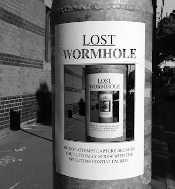

```python
### This inserts an image in the output cell

Image(filename='images/lost_wormhole.jpg',width=500)
```

```python
### This embeds a video from YouTube
### You can embed Vimeo videos by calling from IPython.display import VimeoVideo

# Fernando Pérez at PyConCA, here I start at 30 minutes
YouTubeVideo('F4rFuIb1Ie4', start = 30*60)
```

[video not shown]

```python
### You can also embed a LOCAL video in the notebook, but have to encode it: Not sure it will work
### on Windows ...

import io
import base64

filename = './data/Astro_ML_PYDATA2012.mp4'

video = io.open(filename, 'r+b').read()
encoded = base64.b64encode(video)
HTML(data='''<video alt="AstroML talk" controls>
           <source src="data:video/mp4;base64,{0}" type="video/mp4" />
           </video>'''.format(encoded.decode('ascii')))
```

### Inline plots with matplotlib

```python
import numpy as np
import matplotlib.pyplot as plt
```

```python
# this is a magic IPython command (%) allowing matplotlib plots to be displayed inline in the notebook
%matplotlib inline
```

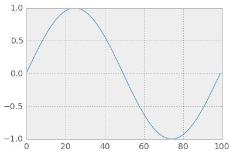

```python
t = np.linspace(0, 2*np.pi, 100)
plt.plot(np.sin(t))
```

```python
# you can also choose to display figure OUTSIDE the notebook
# the available backends are [inline|qt|osx|gtx] ... For Windows try qt
%matplotlib osx
```

```python
t = np.linspace(0, 2*np.pi, 100)
plt.plot(np.sin(t))
```

```python
%matplotlib inline
```

### Some useful magic commands in IPython

```
%lsmagic
```

for a list of available magic command

```python
%lsmagic
```

For example

```
%whos
```

list all variables (incl. classes, functions, etc) in the **namespace**

```python
%whos
```

#### Writing the content of a cell to file

```python
%%file tmp.py
#!/usr/bin/env python
import numpy as np

print('Hello world')

a = np.arange(10) ### will be available in the namespace
```

```
Writing tmp.py
```

#### Running some external python script (local or online)

```python
%run tmp.py
```

```
Hello world
```

```python
a
```

```
array([0, 1, 2, 3, 4, 5, 6, 7, 8, 9])
```

#### Loading the content of some local python script (you can load actually anything, e.g. a Markdown file)

```python
%load tmp.py
```

```python
#!/usr/bin/env python
import numpy as np

print('Hello world')

a = np.arange(10) ### will be available in the namespace
```

```python
#!/usr/bin/env python
import numpy as np

print('Hello world')

a = np.arange(10) ### will be available in the namespace
```

```
Hello world
```

#### works as well for scripts available online

```python
### loading an example from the matplotlib gallery

%load http://matplotlib.org/mpl_examples/images_contours_and_fields/streamplot_demo_features.py
```

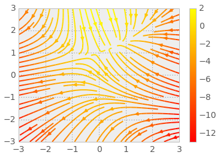

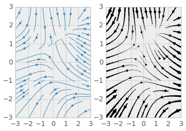

```python
"""
Demo of the `streamplot` function.

A streamplot, or streamline plot, is used to display 2D vector fields. This
example shows a few features of the stream plot function:

    * Varying the color along a streamline.
    * Varying the density of streamlines.
    * Varying the line width along a stream line.
"""
import numpy as np
import matplotlib.pyplot as plt

Y, X = np.mgrid[-3:3:100j, -3:3:100j]
U = -1 - X**2 + Y
V = 1 + X - Y**2
speed = np.sqrt(U*U + V*V)

plt.streamplot(X, Y, U, V, color=U, linewidth=2, cmap=plt.cm.autumn)
plt.colorbar()

f, (ax1, ax2) = plt.subplots(ncols=2)
ax1.streamplot(X, Y, U, V, density=[0.5, 1])

lw = 5*speed/speed.max()
ax2.streamplot(X, Y, U, V, density=0.6, color='k', linewidth=lw)

plt.show()
```

### Interacting with the OS: the IPython notebook as an enhanced shell

```python
!rm tmp.py  ### ! escapes to the OS (!del tmp.py on windows)
```

```python
notebooks = !ls ?_*.ipynb ### notebooks is a python list ... not sure how to use wildcards on Windows
```

```python
notebooks
```

```
['0_Introduction.ipynb',
 '1_Overview_IPython.ipynb',
 '2_Introduction_to_Python.ipynb',
 '3_Numpy_and_Scipy.ipynb',
 '4_Statistical_modelling.ipynb',
 '5_Introduction_to_Pandas.ipynb',
 '6_Machine_Learning-wineexample.ipynb',
 '6_Machine_Learning.ipynb']
```

And if you need to actually quickly put together and run a bash script (linux / Mac), you don't need to escape the IPython notebook thanks to the

```
%%bash
```

cell magic ...

```python
%%bash

# Substitutes underscores for blanks in all the filenames in a directory.

ONE=1                     # For getting singular/plural right (see below).
number=0                  # Keeps track of how many files actually renamed.
FOUND=0                   # Successful return value.

for filename in *         # Traverses all files in directory.
do
     echo "$filename" | grep -q " "         # Checks whether filename
     if [ $? -eq $FOUND ]                   # contains space(s).
     then
       fname=$filename                      # Strips off path.
       n=`echo $fname | sed -e "s/ /_/g"`   # Substitutes underscore for blank.
       mv "$fname" "$n"                     # Do the actual renaming.
       let "number += 1"
     fi
done

if [ "$number" -eq "$ONE" ]                 # For correct grammar.
then
 echo "$number file renamed."
else
 echo "$number files renamed."
fi

exit 0
```

### Exporting your notebook in other formats

A notebook (extension .ipynb) is actually just a JSON file, using built-in converters (with the help of [pandoc](http://johnmacfarlane.net/pandoc/)) you can convert a notebook into a variety of formats for sharing, illustration, publishing, etc.

```python
#!ipython nbconvert --help
!/Users/nicolasfauchereau/anaconda/bin/ipython nbconvert --help
```

```python
# needs pandoc installed (http://johnmacfarlane.net/pandoc/installing.html)
#! ipython nbconvert 1_Overview_IPython.ipynb --to html
!/Users/nicolasfauchereau/anaconda/bin/ipython nbconvert 1_Overview_IPython.ipynb --to html
```

And finally `%quickref` will give you a reference sheet for IPython

```python
%quickref
```